# Example R Code for SoTL projects

Ashley Yue Mao

2023-09-12

# 0. Install and load required packages

Packages you might use:

- **tidyverse**: a collection of packages that you’re likely to use in everyday data analyses.
- **psych**: a package for conducting psychological research
- **lavaan**: a package for fitting latent variable models
- **gtsummary**: a package for creating summary tables
- **report**: a package for reporting statistical results

In order to use a package, you need to install it to your computer (once) and load it every time when you start a new R session. As an example, here is how you can install and load a package:

```r
if (require(tidyverse)){
  install.packages("tidyverse")}

if (require(psych)){
  install.packages("psych")}

if (require(lavaan)){
  install.packages("lavaan")}

if (require(gtsummary)){
  install.packages("gtsummary")}

if (require(report)){
  install.packages("report")}
```

```r
library(tidyverse)
library(psych)
library(lavaan)
library(gtsummary)
library(report)
```

# 1. Data reading

Download survey data as .csv files from [Qualtrics](https://it.ubc.ca/services/teaching-learning-tools/survey-tool) and then you can use `read_csv` functions to read your data.

In this document, I will use three simulated data files:

- a file that contains an identifier for each student, their grades before the intervention, and a two-factor wellbeing measure, each with 4 items, named from WB1_1 to WB1_4 and WB2_1 to WB2_4
- a file that contains an identifier for each student, their grades after the intervention, and a two-factor wellbeing measure, each with 4 items, named from WB1_1 to WB1_4 and WB2_1 to WB2_4
- a file that contains an identifier for each student and their gender and group (e.g., experimental, control)

```r
pre <- read_csv("data/pre_grades.csv")
post <- read_csv("data/post_grades.csv")
info <- read_csv("data/info.csv")
```

As for importing other types of data, such as SPSS, SAS, and JASON, check the [datacamp](https://www.datacamp.com/tutorial/r-data-import-tutorial).

Let’s have a look at the data:

```r
str(pre)
str(post)
str(info)

View(pre)
View(post)
View(info)
```

# 2. Data cleaning

## 2.1 Duplicates

```r
pre_unique <- pre[!duplicated(pre$Identifier), ]
post_unique <- post[!duplicated(post$identifier), ]
```

Note that these codes keep the record associated with any ID that shows up earlier.

If, for some reason, it makes better sense to keep the record associated with any ID that shows up later, add the argument `fromLast = TRUE`, e.g., `pre_unique <- pre[!duplicated(pre$Identifier, fromLast = TRUE), ]`.

If somehow it makes better sense to examine the data more closely and determine which record to keep based on completeness or other reasons, it would be good to write a document of how the inclusion and exclusion were determined. I recommend filtering all the duplicates, adding a row number, scrutinizing the data to determine which record to keep or delete, putting the corresponding row numbers into a vector, and filtering the data based on the vector (i.e., the row numbers).

## 2.2 Reverse coding

Assuming that the second and third items of the first well-being factor should be reverse coded, here is the code for reverse coding.

```r
pre_unique$WB1_2 <- 7- pre_unique$WB1_2 # as it ranges from 1 to 6
pre_unique$WB1_3 <- 7- pre_unique$WB1_3

post_unique$WB1_2 <- 7- post_unique$WB1_2
post_unique$WB1_3 <- 7- post_unique$WB1_3
```

## 2.3 Missing values

List-wise deletion is the simplest if it makes sense.

```r
pre_unique <- pre_unique[complete.cases(pre_unique), ]
post_unique <- post_unique[complete.cases(post_unique), ]
```

More about [missing values](https://r4ds.hadley.nz/missing-values).

# 3. Data joins and computes

## 3.1 Joins

A common task is combining the three datasets for further analysis.

- rename column names in pre and post-grade data to be consistent
- add a new column to keep the record which time the grades belong in the new dataset
- depending on the analyses you plan to do in the next step, you may want combined data in [long format or wide format](https://www.statology.org/long-vs-wide-data/)
- combing the info data

```r
pre_unique <- pre_unique |>
  rename("identifier" = "Identifier",
         "grades" = "Scores") |>
  add_column(time = "pre")

post_unique <- post_unique |>
  add_column(time = "post")

data_long <- pre_unique |>
  bind_rows(post_unique) |>
  inner_join(info, by = "identifier")

data_wide <- pre_unique|>
  inner_join(post_unique, by = "identifier",
             suffix = c(".pre", ".post")) |>
  inner_join(info, by = "identifier")
```

More about [data manipulation](https://ubc-library-rc.github.io/data-manipulation-dplyr/), such as renaming.

More about [join tables](https://ubc-library-rc.github.io/relational-data-r/).

Note that if we directly combine the raw pre and post data, combining into a long format usually does not immediately result in an error message, but it will cause a problem in further analysis, which is hard to identify, and combining the data into a wide format will produce a warning message. This is because some students took the survey twice for whatever reason. We need to deal with duplicates first.

```r
long <- pre |>
  bind_rows(post)

wide <- pre|>
  inner_join(post, by = "identifier")
```

```
Warning: Detected an unexpected many-to-many relationship between `x` and `y`.
```

## 3.2 Composite scores

The simple sum score of the items for each factor:

```r
data_long$WB1 = rowSums(data_long[,c('WB1_1',
                                     'WB1_2',
                                     'WB1_3',
                                     'WB1_4')], na.rm=TRUE)

data_long$WB2 = rowSums(data_long[,c('WB2_1',
                                     'WB2_2',
                                     'WB2_3',
                                     'WB2_4')], na.rm=TRUE)
```

Factor scores:

```r
wb <- 'f1 =~ WB1_1 + WB1_2 + WB1_3 + WB1_4
       f2 =~ WB2_1 + WB2_2 + WB2_3 + WB2_4'
mwb <- cfa(wb, data = data_long, std.lv = TRUE)
data_long$WB1_f <- as.data.frame(lavPredict(mwb))$f1
data_long$WB2_f <- as.data.frame(lavPredict(mwb))$f2
```

# 4. Common psychometric properties

## 4.1 Reliability/ Cronbach’s alpha

```r
alpha(data_long[,c('WB1_1', 'WB1_2', 'WB1_3', 'WB1_4')])
alpha(data_long[,c('WB2_1', 'WB2_2', 'WB2_3', 'WB2_4')])
```

## 4.2 Validity/ Confirmatory factor analysis

```r
wb <- 'f1 =~ WB1_1 + WB1_2 + WB1_3 + WB1_4
       f2 =~ WB2_1 + WB2_2 + WB2_3 + WB2_4'
mwb <- cfa(wb, data = data_long, std.lv = TRUE)
summary(mwb)
```

# 5. Descriptive stats

## 5.1 Categorical variables

```r
table(data_wide$gender) # single variable
table(data_wide$group)

table(data_wide$gender, data_wide$group) # two variables
```

## 5.2 Quantitative variables

```r
describe(data_wide$grades.x)
```

## 5.3 Descriptive summary tables

```r
data_long |>
  select(time, grades, gender, group, WB1, WB2) |>
  tbl_summary(by = time,
              type = all_continuous() ~ "continuous2",
              statistic = list(all_continuous() ~ c("{mean} ({sd})")),
              digits = all_continuous() ~ 2)
```

More about [summary tables](https://www.danieldsjoberg.com/gtsummary/articles/tbl_summary.html).

# 6. Visualization

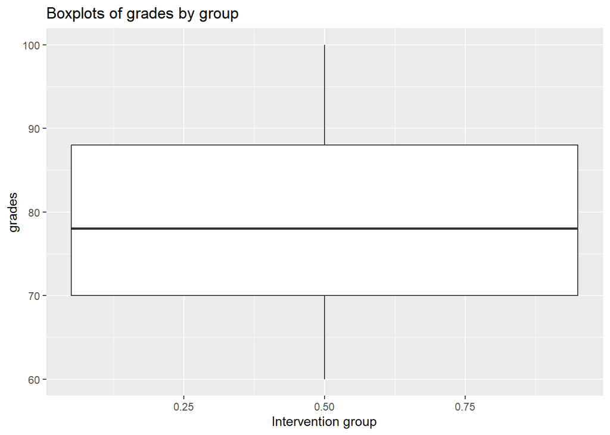

```r
data_long |>
  ggplot(aes(x = group, y = grades, fill = group)) +
    geom_boxplot(outlier.size = 1) +
    labs(title = "Boxplots of grades by group",
         x = "Intervention group", y = "grades")
```

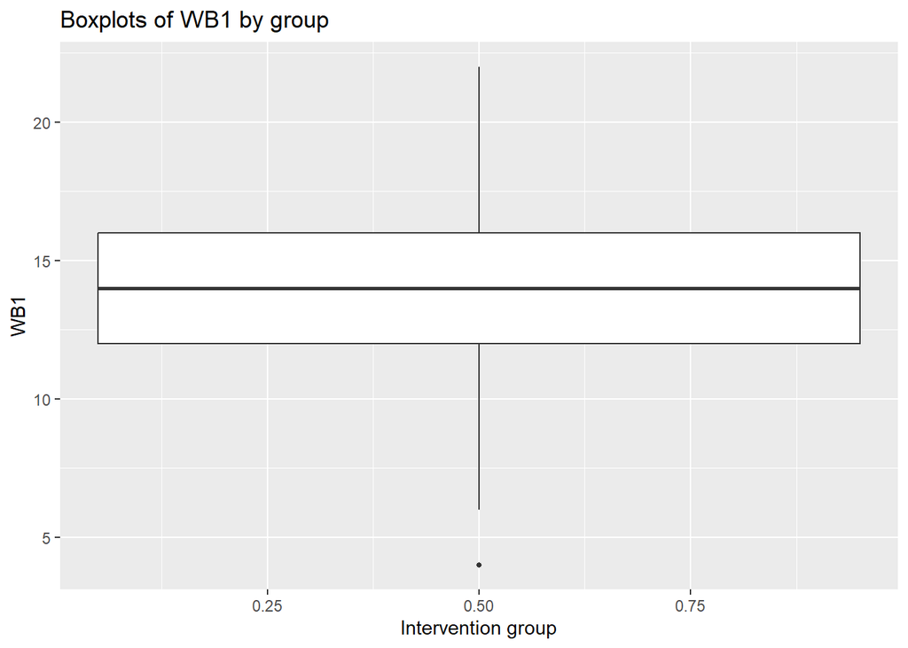

```r
data_long |>
  ggplot(aes(x = group, y = WB1, fill = group)) +
    geom_boxplot(outlier.size = 1) +
    labs(title = "Boxplots of WB1 by group",
         x = "Intervention group", y = "WB1")
```

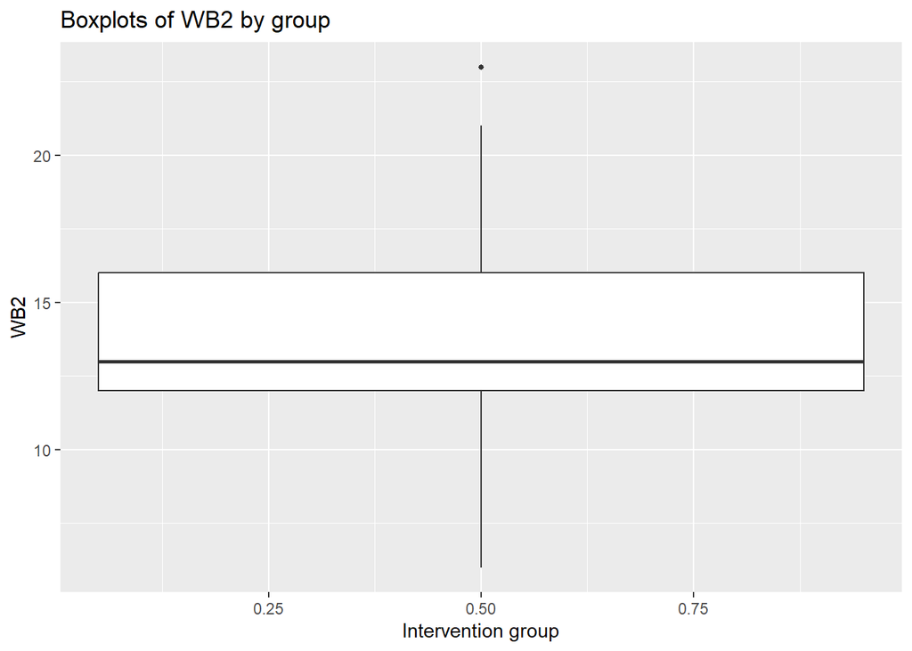

```r
data_long |>
  ggplot(aes(x = group, y = WB2, fill = group)) +
    geom_boxplot(outlier.size = 1) +
    labs(title = "Boxplots of WB2 by group",
         x = "Intervention group", y = "WB2")
```

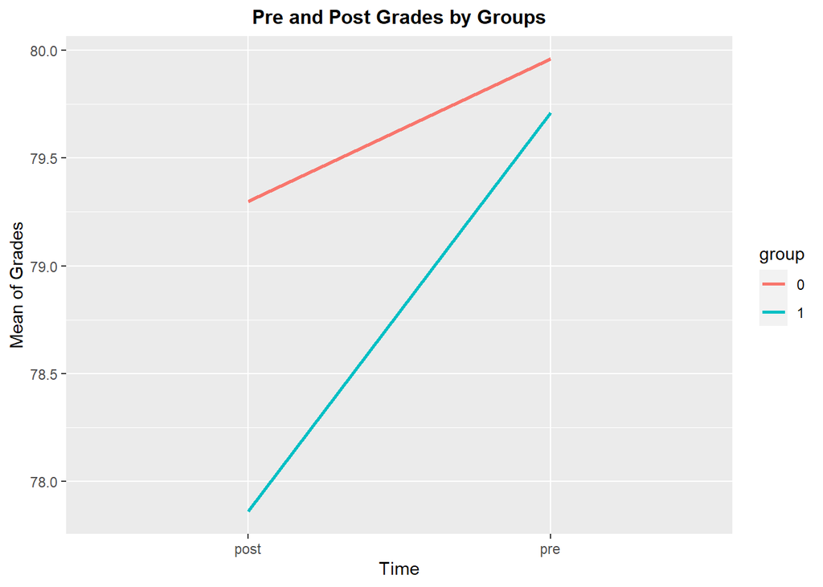

```r
data_long |>
  mutate(group = as.factor(group)) |>
  group_by(group, time) |>
  summarise(mean_grades = mean(grades), .groups = "drop") |>
  ggplot(aes(time, mean_grades, color = group, group = group)) +
  geom_line(linewidth = 1) +
  labs(x = "Time", y = "Mean of Grades", color = "group",
       title = 'Pre and Post Grades by Groups') +
  theme(plot.title = element_text(hjust = 0.5, # horizontal justification
                                  face = 'bold',
                                  size = 12))
```

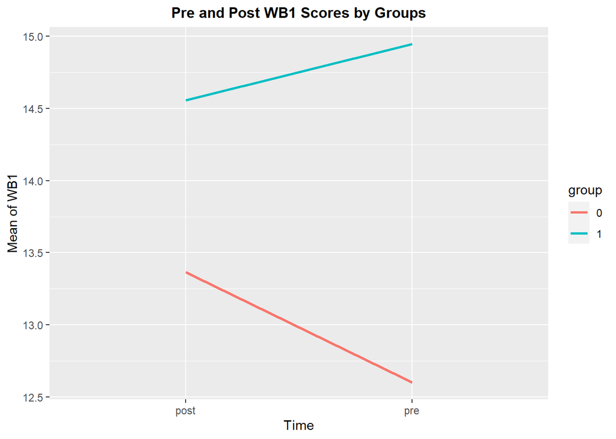

```r
data_long %>%
  mutate(group = as.factor(group)) |>
  group_by(group, time) |>
  summarise(mean_WB1 = mean(WB1), .groups = "drop") |>
  ggplot(aes(time, mean_WB1, color = group, group = group)) +
  geom_line(linewidth = 1) +
  labs(x = "Time", y = "Mean of WB1", color = "group",
       title = 'Pre and Post WB1 Scores by Groups') +
  theme(plot.title = element_text(hjust = 0.5, # horizontal justification
                                  face = 'bold',
                                  size = 12))
```

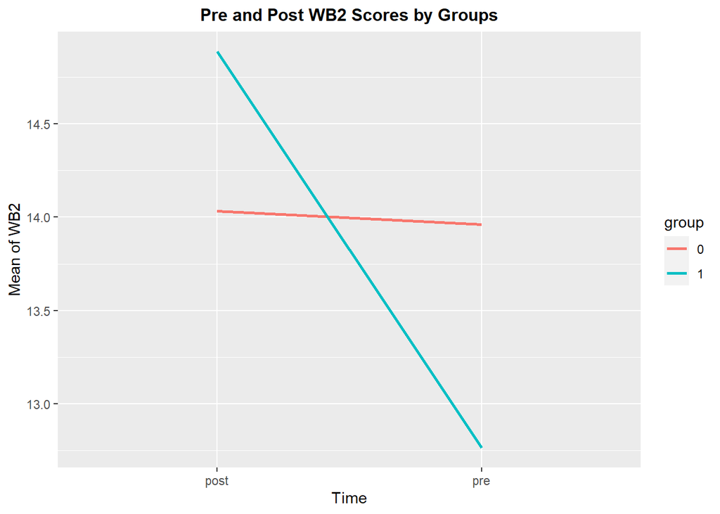

```r
data_long %>%
  mutate(group = as.factor(group)) |>
  group_by(group, time) |>
  summarise(mean_WB2 = mean(WB2), .groups = "drop") |>
  ggplot(aes(time, mean_WB2, color = group, group = group)) +
  geom_line(linewidth = 1) +
  labs(x = "Time", y = "Mean of WB2", color = "group",
       title = 'Pre and Post WB2 Scores by Groups') +
  theme(plot.title = element_text(hjust = 0.5, # horizontal justification
                                  face = 'bold',
                                  size = 12))
```

# 7. Inferential stats

Note. Assumptions of each of the following tests need to be considered and examined.

## 7.1 One sample t-test

It is used to see whether the hypothesized value of the population mean matches actual value.

Question: Is the average grades 85?

```r
m1 <- t.test(data_long$grades, mu = 85,
       alternative = c("two.sided"),
       conf.level = 0.95)
summary(m1)
report(m1)
```

## 7.2 Two sample independent t-test

It is used to see whether there are group differences in population means between two groups.

Question: Do intervention and non-intervention group has same average grades?

```r
m2 <- t.test(grades ~ group, var.eq = TRUE, data = data_long)
summary(m2)
report(m2)
```

## 7.3 Paired sample t-test

It is used to see whether there are differences in population means between two times or two conditions.

Question: Do students’ post grades increased compared to the pre grades?

```r
m3 <- t.test(data_wide$grades.pre, data_wide$grades.post, var.eq = TRUE, paired = TRUE, data = data_wide)
summary(m3)
report(m3)
```

## 7.4 One-way ANOVA

It is used to determine whether there are group differences in numeric data between two or more groups.

Question: Do grades significantly differ by gender groups (male, female, prefer not to answer)?

```r
m4 <- aov(grades ~ gender, data = data_long)
summary(m4)
report(m4)
```

## 7.5 Two way ANOVA

It is used to determine whether there are group differences in numeric data between groups characterized by two different categorical variables.

Question: Do grades significantly differ by gender and intervention group?

```r
m5 <- aov(grades ~ gender + group, data = data_long)
summary(m5)
report(m5)
```

## 7.6 Repeated measure ANOVA

It is used to see whether there are differences in population means under three or more times or conditions.

Assuming we have three time posts,

Question: Do grades changes along the time?

```r
m6 <- aov(grades ~ factor(time) + Error(factor(identifier)), data = data_long)
summary(m6)
report(m6)
```

## 7.7 Mixed design ANOVA

It is to test for differences between two or more independent groups whilst subjecting participants to repeated measures.

Question: Do the grades of the intervention and non-intervention groups change differently?

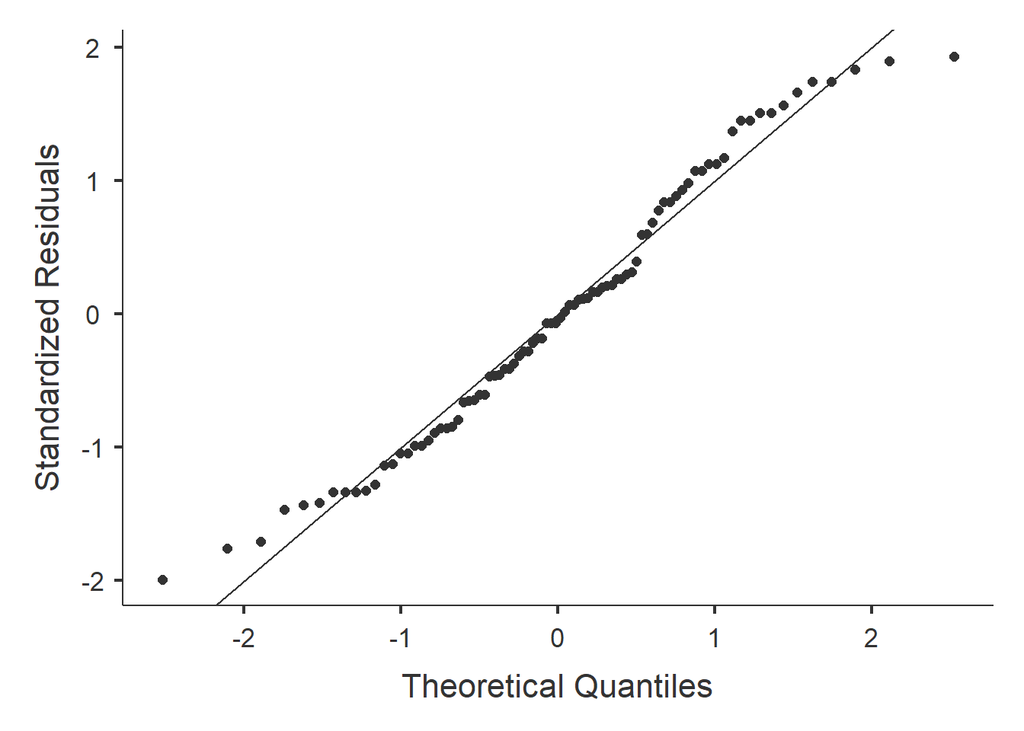

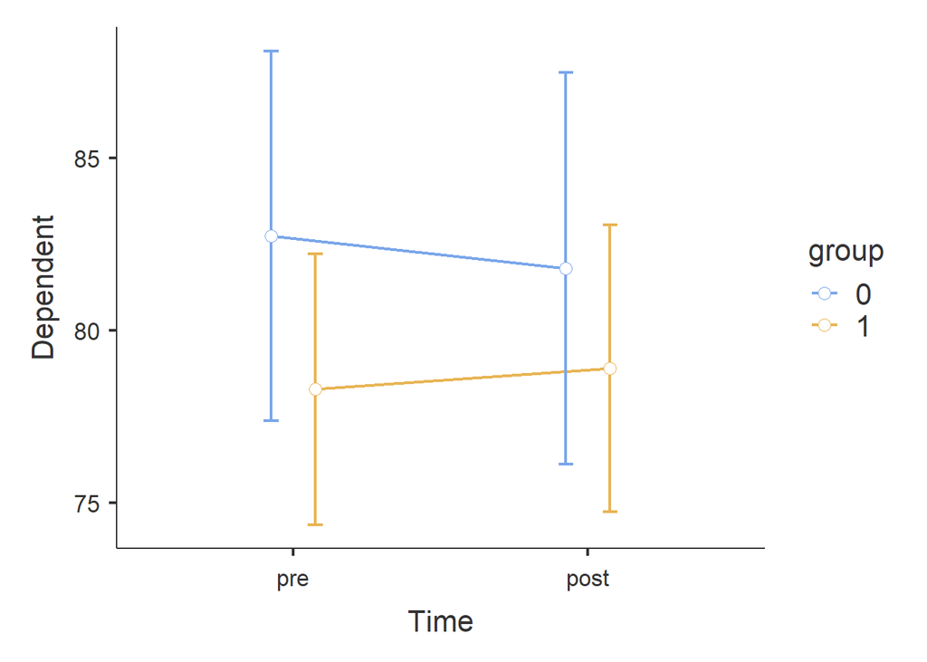

```r
jmv::anovaRM(
  data = data_wide,
  rm = list(
    list(
      label="Time",
      levels=c("pre", "post"))),
  rmCells = list(
    list(
      measure="grades.pre",
      cell="pre"),
    list(
      measure="grades.post",
      cell="post")),
  bs = group,
  effectSize = "partEta",
  rmTerms = ~ Time,
  bsTerms = ~ group,
  spherTests = TRUE,
  leveneTest = TRUE,
  qq = TRUE,
  postHoc = list(
    c("Time", "group")),
  postHocCorr = "bonf",
  emMeans = ~ Time:group,
  emmTables = TRUE,
  groupSumm = TRUE)
```